# Practical 3

```r
#read the package and layer
library(sf)
library(here)
st_layers(here("prac3_data", "gadm36_AUS.gpkg"))
```

```
Driver: GPKG
Available layers:
```

| layer_name | geometry_type | features | fields | crs_name |
| --- | --- | --- | --- | --- |
| gadm36_AUS_0 | Multi Polygon | 1 | 2 | WGS 84 |
| gadm36_AUS_1 | Multi Polygon | 11 | 10 | WGS 84 |
| gadm36_AUS_2 | Multi Polygon | 569 | 13 | WGS 84 |

```r
Ausoutline <- st_read(here("prac3_data", "gadm36_AUS.gpkg"),
                      layer='gadm36_AUS_0')
print(Ausoutline)
```

```
Simple feature collection with 1 feature and 2 fields
Geometry type: MULTIPOLYGON
Dimension:     XY
Bounding box:  xmin: 112.9211 ymin: -55.11694 xmax: 159.1092 ymax: -9.142176
Geodetic CRS:  WGS 84
  GID_0    NAME_0                           geom
1   AUS Australia MULTIPOLYGON (((158.6928 -5...
```

```r
st_crs(Ausoutline)$proj4string
```

```
[1] "+proj=longlat +datum=WGS84 +no_defs"
```

```r
#only useful if there is no CRS
Ausoutline <- Ausoutline %>%
  st_set_crs(., 4326)
```

```r
# re-project or transform CRS
AusoutlinePROJECTED <- Ausoutline %>%
  st_transform(.,3112) # GDA94, a local CRS for Australia

print(AusoutlinePROJECTED)
```

```
Simple feature collection with 1 feature and 2 fields
Geometry type: MULTIPOLYGON
Dimension:     XY
Bounding box:  xmin: -2083066 ymin: -6460625 xmax: 2346599 ymax: -1115948
Projected CRS: GDA94 / Geoscience Australia Lambert
  GID_0    NAME_0                           geom
1   AUS Australia MULTIPOLYGON (((1775780 -64...
```

```r
##From sf to sp
#AusoutlineSP <- Ausoutline %>%
#  as(., "Spatial")

##From sp to sf
#AusoutlineSF <- AusoutlineSP %>%
#  st_as_sf()
```

```r
library(raster)
library(terra)
jan<-terra::rast(here("prac3_data", "wc2.1_5m_tavg_01.tif"))
# have a look at the raster layer jan
jan
```

```
class       : SpatRaster
dimensions  : 2160, 4320, 1  (nrow, ncol, nlyr)
resolution  : 0.08333333, 0.08333333  (x, y)
extent      : -180, 180, -90, 90  (xmin, xmax, ymin, ymax)
coord. ref. : lon/lat WGS 84 (EPSG:4326)
source      : wc2.1_5m_tavg_01.tif
name        : wc2.1_5m_tavg_01
min value   :          -46.042
max value   :           34.065
```

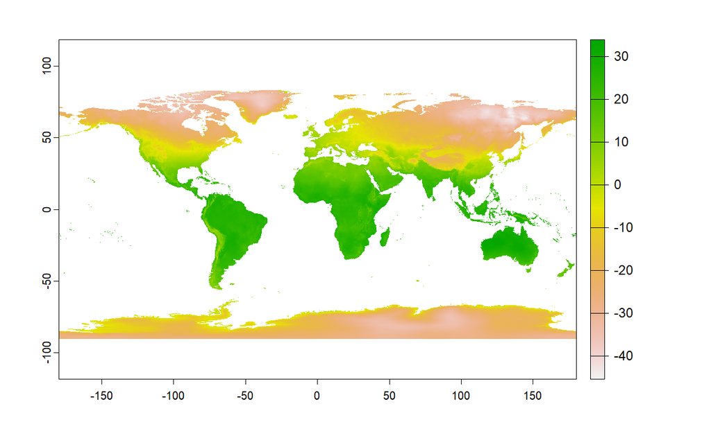

```r
plot(jan)
```

using the Mollweide projection saved to a new object. The Mollweide projection retains area proportions whilst compromising accuracy of angle and shape

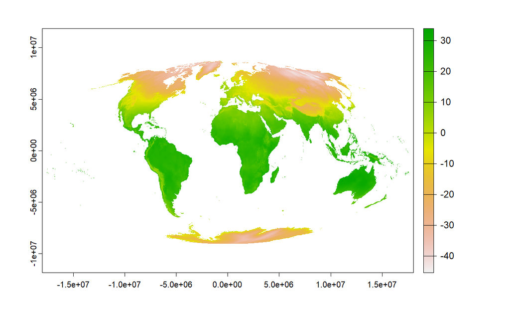

```r
# set the proj 4 to a new object

pr1 <- terra::project(jan, "+proj=moll +lon_0=0 +x_0=0 +y_0=0 +ellps=WGS84 +datum=WGS84 +units=m +no_defs")

#or....

newproj<-"ESRI:54009"
# get the jan raster and give it the new proj4
pr1 <- jan %>%
  terra::project(., newproj)
plot(pr1)
```

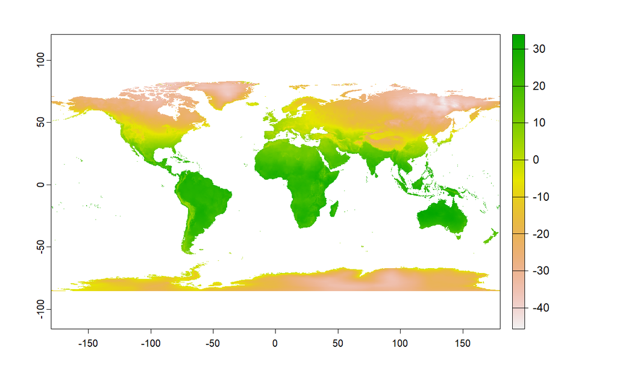

```r
#back to WGS 84
pr1 <- pr1 %>%
  terra::project(., "EPSG:4326")
plot(pr1)
```

```r
# look in our folder, find the files that end with .tif and
library(fs)
dir_info("D:/CASA/GIS/prac3_data/")
```

| path | type | size | permissions | modification_time | user | group | device_id | hard_links | special_device_id | inode | block_size | blocks | flags | generation | access_time | change_time | birth_time |
| --- | --- | --- | --- | --- | --- | --- | --- | --- | --- | --- | --- | --- | --- | --- | --- | --- | --- |
| D:/CASA/GIS/prac3_data/gadm36_AUS.gpkg | file | 83.6M | rw- | 2018-05-06 20:25:22 | NA | NA | 504186349 | 1 | 0 | 2.81475e+14 | 4096 | 171160 | 0 | 0 | 2022-10-26 10:51:38 | 2022-10-23 22:46:17 | 2022-10-23 22:46:17 |
| D:/CASA/GIS/prac3_data/license.txt | file | 300 | rw- | 2018-05-06 21:12:53 | NA | NA | 504186349 | 1 | 0 | 2.81475e+14 | 4096 | 0 | 0 | 0 | 2022-10-23 22:46:17 | 2022-10-23 22:46:17 | 2022-10-23 22:46:17 |
| D:/CASA/GIS/prac3_data/wc2.1_5m_tavg_01.tif | file | 10.5M | rw- | 2019-02-18 16:42:40 | NA | NA | 504186349 | 1 | 0 | 1.68885e+15 | 4096 | 21520 | 0 | 0 | 2022-10-26 10:57:20 | 2022-10-25 22:19:39 | 2022-10-25 22:19:39 |
| D:/CASA/GIS/prac3_data/wc2.1_5m_tavg_02.tif | file | 10.6M | rw- | 2019-02-18 17:02:10 | NA | NA | 504186349 | 1 | 0 | 1.12590e+15 | 4096 | 21640 | 0 | 0 | 2022-10-25 22:46:08 | 2022-10-25 22:19:39 | 2022-10-25 22:19:39 |
| D:/CASA/GIS/prac3_data/wc2.1_5m_tavg_03.tif | file | 10.6M | rw- | 2019-02-18 17:22:18 | NA | NA | 504186349 | 1 | 0 | 5.62950e+14 | 4096 | 21792 | 0 | 0 | 2022-10-25 22:46:08 | 2022-10-25 22:19:39 | 2022-10-25 22:19:39 |
| D:/CASA/GIS/prac3_data/wc2.1_5m_tavg_04.tif | file | 10.7M | rw- | 2019-02-18 17:42:00 | NA | NA | 504186349 | 1 | 0 | 5.62950e+14 | 4096 | 21904 | 0 | 0 | 2022-10-25 22:46:08 | 2022-10-25 22:19:40 | 2022-10-25 22:19:39 |
| D:/CASA/GIS/prac3_data/wc2.1_5m_tavg_05.tif | file | 10.7M | rw- | 2019-02-18 18:01:44 | NA | NA | 504186349 | 1 | 0 | 5.62950e+14 | 4096 | 21920 | 0 | 0 | 2022-10-25 22:46:08 | 2022-10-25 22:19:40 | 2022-10-25 22:19:40 |
| D:/CASA/GIS/prac3_data/wc2.1_5m_tavg_06.tif | file | 10.6M | rw- | 2019-02-18 18:21:48 | NA | NA | 504186349 | 1 | 0 | 5.62950e+14 | 4096 | 21704 | 0 | 0 | 2022-10-25 22:46:08 | 2022-10-25 22:19:40 | 2022-10-25 22:19:40 |
| D:/CASA/GIS/prac3_data/wc2.1_5m_tavg_07.tif | file | 10.5M | rw- | 2019-02-18 18:41:24 | NA | NA | 504186349 | 1 | 0 | 5.62950e+14 | 4096 | 21560 | 0 | 0 | 2022-10-25 22:46:08 | 2022-10-25 22:19:40 | 2022-10-25 22:19:40 |
| D:/CASA/GIS/prac3_data/wc2.1_5m_tavg_08.tif | file | 10.5M | rw- | 2019-02-18 16:15:12 | NA | NA | 504186349 | 1 | 0 | 5.62950e+14 | 4096 | 21464 | 0 | 0 | 2022-10-25 22:46:08 | 2022-10-25 22:19:40 | 2022-10-25 22:19:40 |

[output cut: 4 more lines]

```r
# select the data we actually want
library(tidyverse)
listfiles<-dir_info("D:/CASA/GIS/prac3_data/") %>%
  filter(str_detect(path, ".tif")) %>%
  dplyr::select(path)%>%
  pull()

#have a look at the file names
listfiles
```

```
D:/CASA/GIS/prac3_data/wc2.1_5m_tavg_01.tif D:/CASA/GIS/prac3_data/wc2.1_5m_tavg_02.tif
D:/CASA/GIS/prac3_data/wc2.1_5m_tavg_03.tif D:/CASA/GIS/prac3_data/wc2.1_5m_tavg_04.tif
D:/CASA/GIS/prac3_data/wc2.1_5m_tavg_05.tif D:/CASA/GIS/prac3_data/wc2.1_5m_tavg_06.tif
D:/CASA/GIS/prac3_data/wc2.1_5m_tavg_07.tif D:/CASA/GIS/prac3_data/wc2.1_5m_tavg_08.tif
D:/CASA/GIS/prac3_data/wc2.1_5m_tavg_09.tif D:/CASA/GIS/prac3_data/wc2.1_5m_tavg_10.tif
D:/CASA/GIS/prac3_data/wc2.1_5m_tavg_11.tif D:/CASA/GIS/prac3_data/wc2.1_5m_tavg_12.tif
```

Then load all of the data straight into a SpatRaster. A SpatRaster is a collection of raster layers with the same spatial extent and resolution.

```r
worldclimtemp <- listfiles %>%
  terra::rast()

#have a look at the raster stack
worldclimtemp
```

```
class       : SpatRaster
dimensions  : 2160, 4320, 12  (nrow, ncol, nlyr)
resolution  : 0.08333333, 0.08333333  (x, y)
extent      : -180, 180, -90, 90  (xmin, xmax, ymin, ymax)
coord. ref. : lon/lat WGS 84 (EPSG:4326)
sources     : wc2.1_5m_tavg_01.tif
              wc2.1_5m_tavg_02.tif
              wc2.1_5m_tavg_03.tif
              ... and 9 more source(s)
names       : wc2.1~vg_01, wc2.1~vg_02, wc2.1~vg_03, wc2.1~vg_04, wc2.1~vg_05, wc2.1~vg_06, ...
min values  :     -46.042,     -44.800,     -57.986,     -64.200,     -64.829,     -64.395, ...
max values  :      34.065,      32.908,      33.081,      34.277,      36.299,      38.458, ...
```

```r
# access the january layer
worldclimtemp[[1]]
```

```
class       : SpatRaster
dimensions  : 2160, 4320, 1  (nrow, ncol, nlyr)
resolution  : 0.08333333, 0.08333333  (x, y)
extent      : -180, 180, -90, 90  (xmin, xmax, ymin, ymax)
coord. ref. : lon/lat WGS 84 (EPSG:4326)
source      : wc2.1_5m_tavg_01.tif
name        : wc2.1_5m_tavg_01
min value   :          -46.042
max value   :           34.065
```

```r
#rename the layers
month <- c("Jan", "Feb", "Mar", "Apr", "May", "Jun",
           "Jul", "Aug", "Sep", "Oct", "Nov", "Dec")

names(worldclimtemp) <- month
```

```r
# get data for January using new layer name
worldclimtemp$Jan
```

```
class       : SpatRaster
dimensions  : 2160, 4320, 1  (nrow, ncol, nlyr)
resolution  : 0.08333333, 0.08333333  (x, y)
extent      : -180, 180, -90, 90  (xmin, xmax, ymin, ymax)
coord. ref. : lon/lat WGS 84 (EPSG:4326)
source      : wc2.1_5m_tavg_01.tif
name        :     Jan
min value   : -46.042
max value   :  34.065
```

Using a raster stack we can extract data with a single command!! For example, make a dataframe of some sample sites — Australian cities/towns.

```r
site <- c("Brisbane", "Melbourne", "Perth", "Sydney", "Broome", "Darwin", "Orange",
          "Bunbury", "Cairns", "Adelaide", "Gold Coast", "Canberra", "Newcastle",
          "Wollongong", "Logan City" )
lon <- c(153.03, 144.96, 115.86, 151.21, 122.23, 130.84, 149.10, 115.64, 145.77,
         138.6, 153.43, 149.13, 151.78, 150.89, 153.12)
lat <- c(-27.47, -37.91, -31.95, -33.87, 17.96, -12.46, -33.28, -33.33, -16.92,
         -34.93, -28, -35.28, -32.93, -34.42, -27.64)
#Put all of this inforamtion into one list
samples <- data.frame(site, lon, lat, row.names="site")
# Extract the data from the Rasterstack for all points
AUcitytemp<- terra::extract(worldclimtemp, samples)
```

Add the city names to the rows of AUcitytemp

```r
Aucitytemp2 <- AUcitytemp %>%
  as_tibble()%>%
  add_column(Site = site, .before = "Jan")
```

take Perth as an example. We can subset our data either using the row name:

```r
Perthtemp <- Aucitytemp2 %>%
  filter(site=="Perth")
```

Make a histogram of Perth’s temperature. The tibble stored the data as double and the base hist() function needs it as numeric..

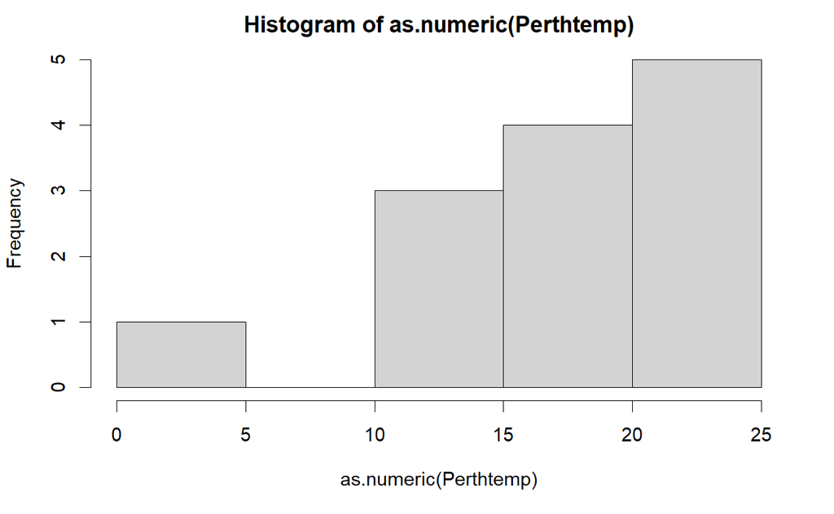

```r
hist(as.numeric(Perthtemp))
```

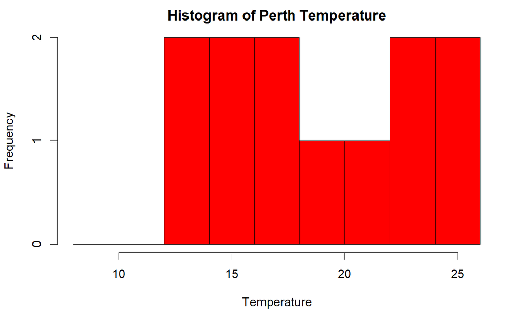

```r
library(tidyverse)
#define where you want the breaks in the historgram
userbreak<-c(8,10,12,14,16,18,20,22,24,26)

# remove the ID and site columns
Perthtemp <- Aucitytemp2 %>%
  filter(site=="Perth")

t<-Perthtemp %>%
 dplyr::select(Jan:Dec)

  hist((as.numeric(t)),
     breaks=userbreak,
     col="red",
     main="Histogram of Perth Temperature",
     xlab="Temperature",
     ylab="Frequency")
```

```r
histinfo
```

[output not shown]

breaks — the cut off points for the bins (or bars), we just specified these counts — the number of cells in each bin midpoints — the middle value for each bin density — the density of data per bin

Check the layer by plotting the geometr

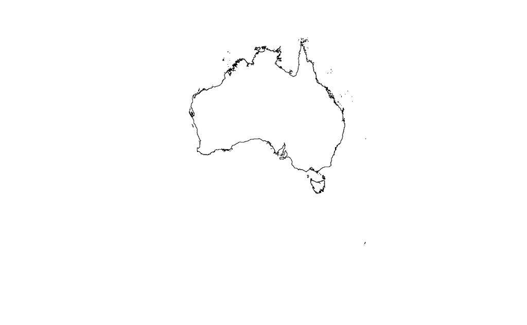

```r
plot(Ausoutline$geom)
```

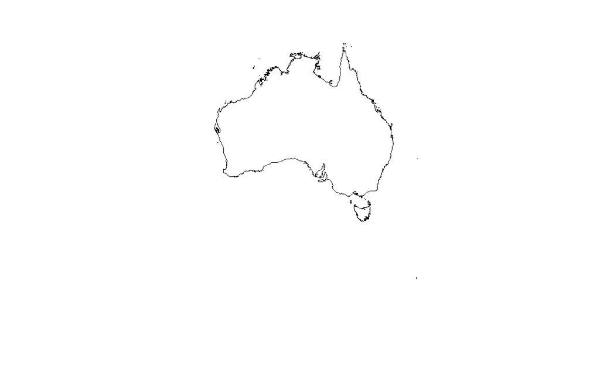

```r
#simplify the .shp with lots of points
AusoutSIMPLE <- Ausoutline %>%
  st_simplify(., dTolerance = 1000) %>% #controls the level of generalisation in the units of the map
  st_geometry()%>%
  plot()
```

make sure that both of our layers are in the same coordinate reference system before combine

```r
print(Ausoutline)
```

```
Simple feature collection with 1 feature and 2 fields
Geometry type: MULTIPOLYGON
Dimension:     XY
Bounding box:  xmin: 112.9211 ymin: -55.11694 xmax: 159.1092 ymax: -9.142176
Geodetic CRS:  WGS 84
  GID_0    NAME_0                           geom
1   AUS Australia MULTIPOLYGON (((158.6928 -5...
```

```r
#this works nicely for rasters
crs(worldclimtemp)
```

```
[1] "GEOGCRS[\"WGS 84\",\n    DATUM[\"World Geodetic System 1984\",\n        ELLIPSOID[\"WGS 84\",6378137,298.257223563,\n            LENGTHUNIT[\"metre\",1]]],\n    PRIMEM[\"Greenwich\",0,\n        ANGLEUNIT[\"degree\",0.0174532925199433]],\n    CS[ellipsoidal,2],\n        AXIS[\"geodetic latitude …
```

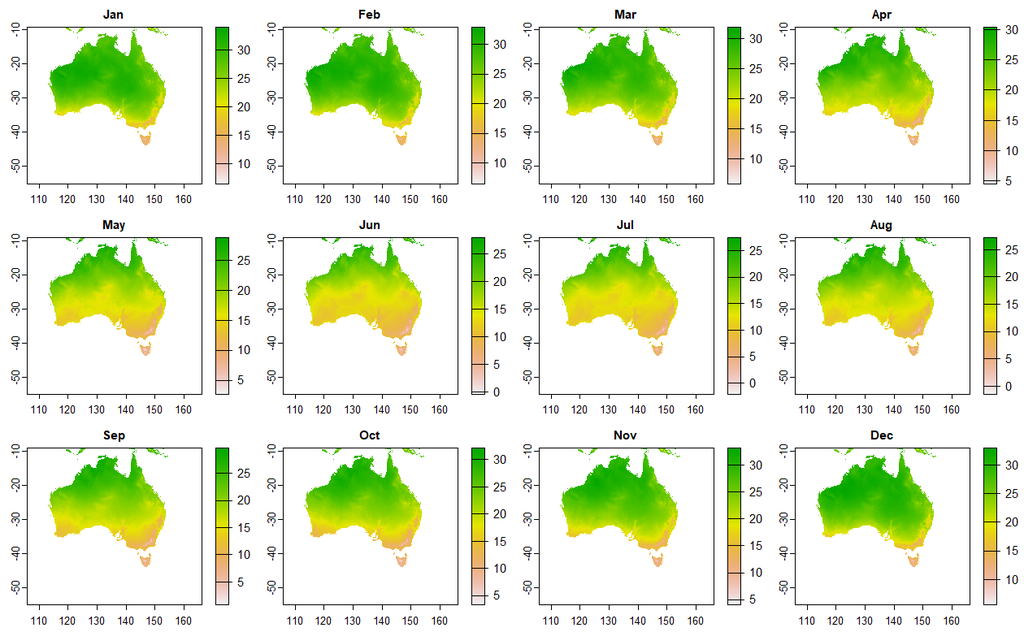

```r
Austemp <- Ausoutline %>%
  # now crop our temp data to the extent
  terra::crop(worldclimtemp,.)

# plot the output
plot(Austemp)
```

```r
exactAus
```

```
class       : SpatRaster
dimensions  : 551, 554, 12  (nrow, ncol, nlyr)
resolution  : 0.08333333, 0.08333333  (x, y)
extent      : 112.9167, 159.0833, -55.08333, -9.166667  (xmin, xmax, ymin, ymax)
coord. ref. : lon/lat WGS 84 (EPSG:4326)
source      : memory
names       :     Jan,      Feb,       Mar,       Apr,    May,    Jun, ...
min values  :  6.4875,  6.53125,  5.845714,  4.571428,  2.642, -0.394, ...
max values  : 34.0650, 32.90800, 31.986000, 30.400000, 28.800, 27.200, ...
```

[output not shown]

[output not shown]

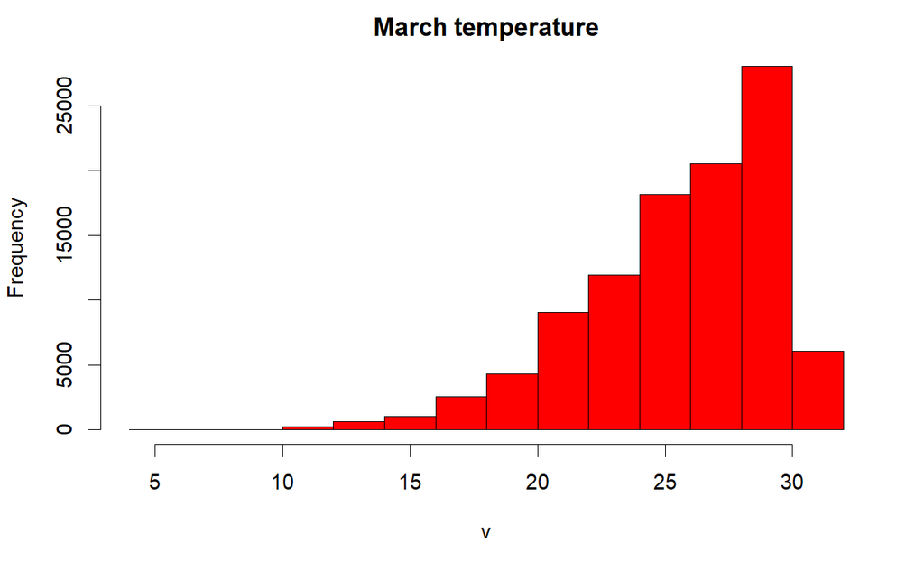

```r
#subset using the known location of the raster
hist(exactAus[[3]], col="red", main ="March temperature")
```

```r
#make our raster into a data.frame to be compatible with ggplot2, using a dataframe or tibble
exactAusdf <- exactAus %>%
  as.data.frame()
```

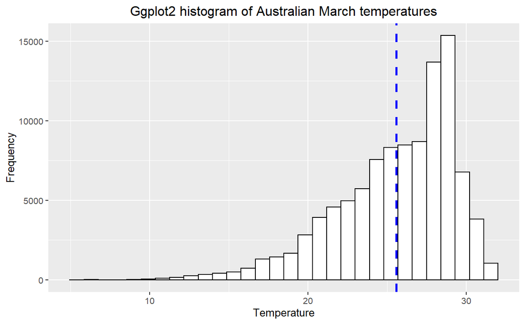

```r
library(ggplot2)
# set up the basic histogram
gghist <- ggplot(exactAusdf,
                 aes(x=Mar)) +
  geom_histogram(color="black",
                 fill="white")+
  labs(title="Ggplot2 histogram of Australian March temperatures",
       x="Temperature",
       y="Frequency")
# add a vertical line to the hisogram showing mean tempearture
gghist + geom_vline(aes(xintercept=mean(Mar,
                                        na.rm=TRUE)),
            color="blue",
            linetype="dashed",
            size=1)+
  theme(plot.title = element_text(hjust = 0.5))
```

select two month

```r
twomonths <- squishdata %>%
  # | = OR
  filter(., Month=="Jan" | Month=="Jun")
```

```r
meantwomonths <- twomonths %>%
  group_by(Month) %>%
  summarise(mean=mean(Temp, na.rm=TRUE))

meantwomonths
```

| Month | mean |
| --- | --- |
| Jan | 27.97927 |
| Jun | 15.08030 |

[figure not shown]

```r
ggplot(twomonths, aes(x=Temp, color=Month, fill=Month)) +
  geom_histogram(position="identity", alpha=0.5)+
  geom_vline(data=meantwomonths,
             aes(xintercept=mean,
                 color=Month),
             linetype="dashed")+
  labs(title="Ggplot2 histogram of Australian Jan and Jun
       temperatures",
       x="Temperature",
       y="Frequency")+
  theme_classic()+
  theme(plot.title = element_text(hjust = 0.5))
```